# Logicout dataset description

# 1 Vocabulary

A round (*Tournée* in French) corresponds to a delivery round. It is composed by a serie of stops where the deliveries are made and trips (or *segment*). A trip is the travel between 2 stops.

# 2 Rounds distance analysis

There is 1097 simulations of trips that are considered as corresponding to real delivery routes. This is on this subset we are working on.

Those simulations have been made by 150 distinct users.

## 2.1 Number of simulations by user

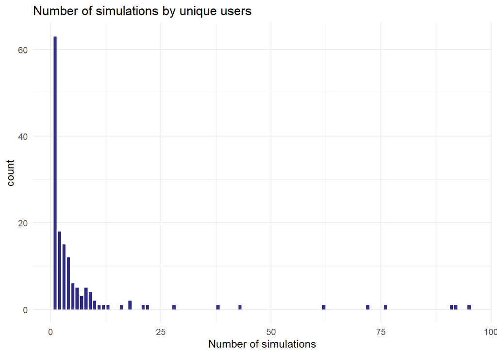

Figure 1: Number of simulations by user

Table 1: Number of simulations by user

| min | mean | median | max |
| --- | --- | --- | --- |
| 1 | 7.3 | 2 | 95 |

The mean number of simulation by user is 7.3133333

63 users (42%) have done only one simulation.

## 2.2 Stops

The number of stops by delivery route is, in average of 5.4339107, where the median is about 4.

There is at least 1 stops (direct delivery) and the maximum is 40.

## 2.3 Stops repartition

Table 2: Number of stops by delivery round

| min | mean | median | max |
| --- | --- | --- | --- |
| 1 | 5.4 | 4 | 40 |

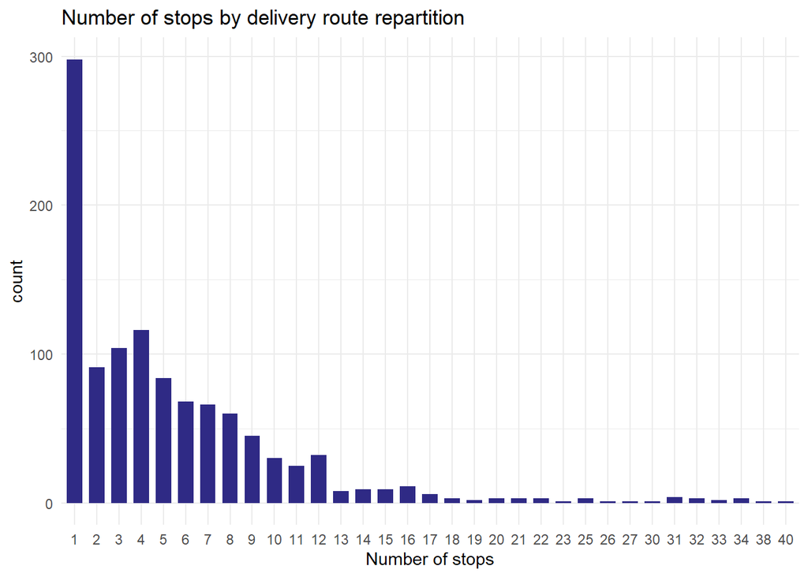

Figure 2: Number of stops by delivery route repartition

### 2.3.1 Rounds with the largest number of stops (more than 30)

| id_simulation | stops |
| --- | --- |
| 18687 | 40 |
| 18751 | 38 |
| 2280 | 34 |
| 11433 | 34 |
| 11435 | 34 |
| 11239 | 33 |
| 11273 | 33 |
| 11264 | 32 |
| 11275 | 32 |
| 11276 | 32 |
| 11431 | 31 |
| 11432 | 31 |
| 12390 | 31 |
| 12539 | 31 |

## 2.4 Rounds

### 2.4.1 Rounds distance (in kilometers)

Table 3: Delivery rounds distances (in kilometers)

| min | mean | median | max |
| --- | --- | --- | --- |
| 0.14 | 25 | 18 | 278 |

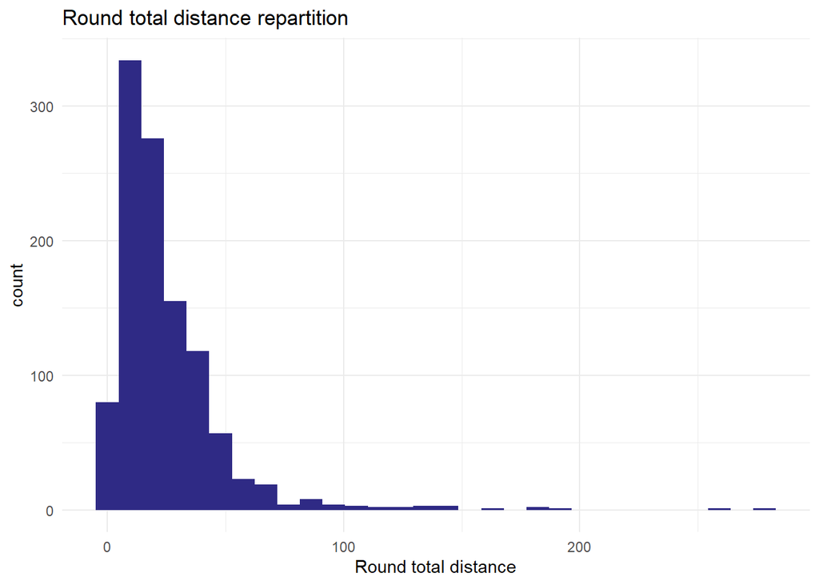

Figure 3: Repartition by total distance of rounds

### 2.4.2 Rounds distance by number of stops ratio

Obviously, the longest rounds should have the more stops. Let’s see that.

Table 4: Longuest delivery rounds (in distance)

| id_simulation | round_distance | stops |
| --- | --- | --- |
| 15376 | 278 | 2 |
| 4220 | 260 | 4 |
| 11595 | 188 | 2 |
| 4729 | 183 | 3 |
| 913 | 178 | 2 |
| 16266 | 159 | 2 |
| 18447 | 146 | 2 |
| 15375 | 144 | 2 |
| 3418 | 140 | 2 |
| 18437 | 137 | 2 |

Well, it does not seems true at all.

Table 5: Distance ratios (distance by number of stops)

| id_simulation | round_distance | stops | ratio |
| --- | --- | --- | --- |
| 15376 | 278 | 2 | 139 |
| 11595 | 188 | 2 | 94 |
| 913 | 178 | 2 | 89 |
| 16266 | 159 | 2 | 80 |
| 18447 | 146 | 2 | 73 |
| 15375 | 144 | 2 | 72 |
| 6668 | 71 | 1 | 71 |
| 3418 | 140 | 2 | 70 |
| 18437 | 137 | 2 | 69 |
| 12343 | 134 | 2 | 67 |

Table 6: Distance ratios (distance by number of stops)

| min | mean | median | max |
| --- | --- | --- | --- |
| 0.03 | 7.4 | 3.4 | 139 |

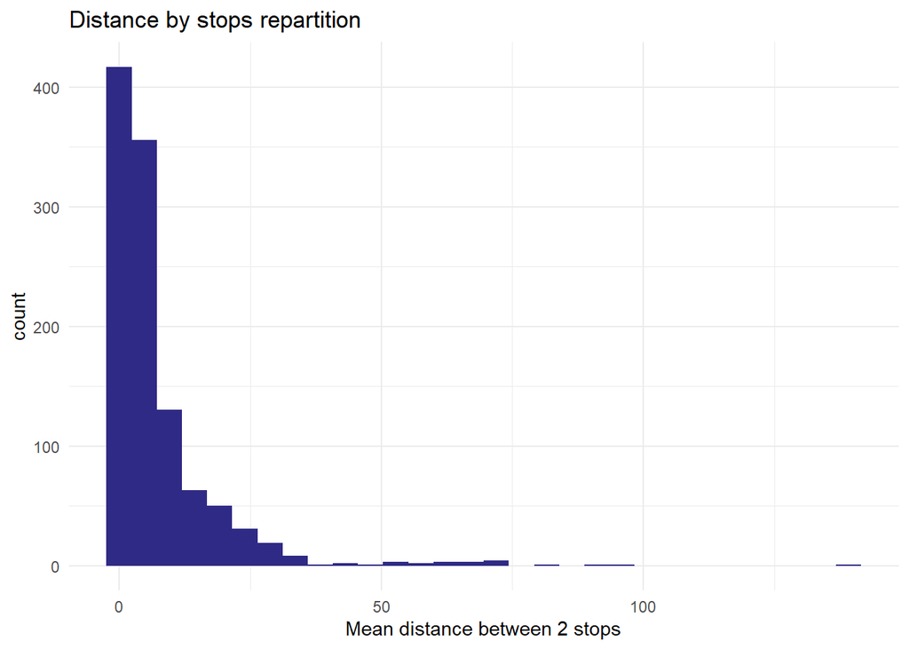

Figure 4: Distance by stops repartition

We can see that stops are generally close to each other (less 5 km in 60% of cases, less than 20 km in 90% of cases).

### 2.4.3 Long trips

This part looks at the rounds where the distance between 2 stops is greater than 18.031 kilometers.

In fact, it seems that it is the opposite, longest trips have very few stops. For those 108 rounds with long trips, the minimal number of stops is 1 and the maximum is 5.

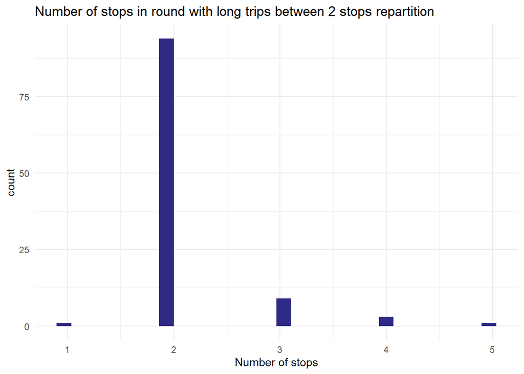

Figure 5: Number of stops in round with long trips between 2 stops repartition

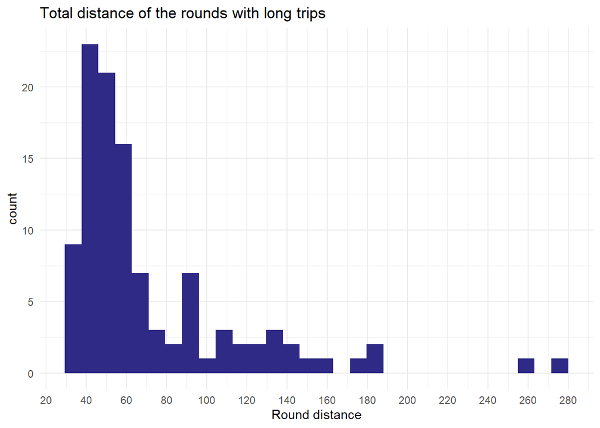

Figure 6: Total distance of the rounds with long trips

# 3 Costs analysis

## 3.1 Driving time

Table 7: Driving time (in minutes), by delivery round

| min | mean | median | max |
| --- | --- | --- | --- |
| 1.4 | 133 | 98 | 673 |

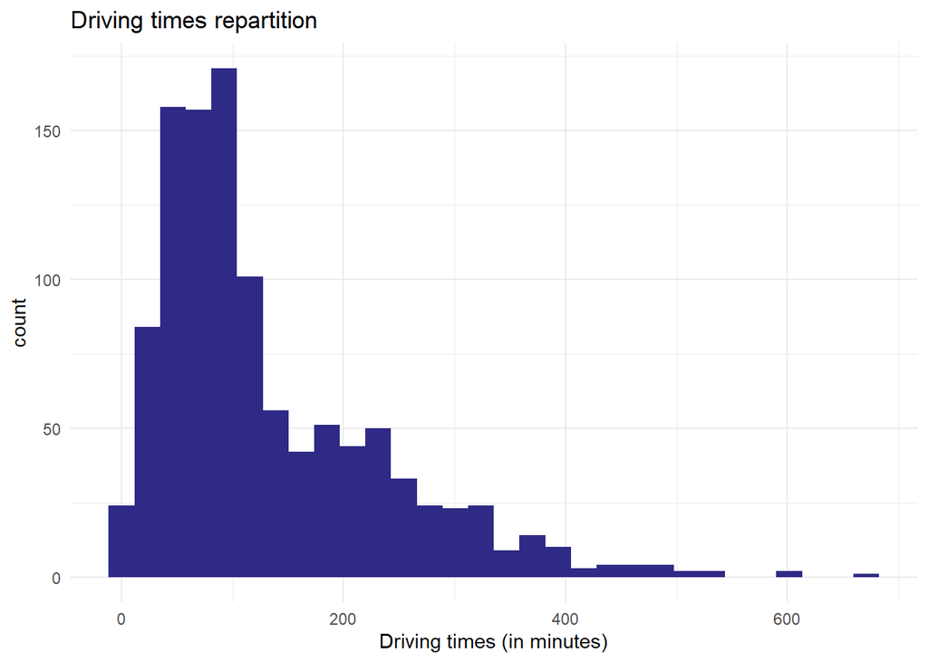

Figure 7: Driving time repartition

## 3.2 Collective cost

| min | mean | median | max |
| --- | --- | --- | --- |
| 0 | 2.5 | 1.1 | 102 |

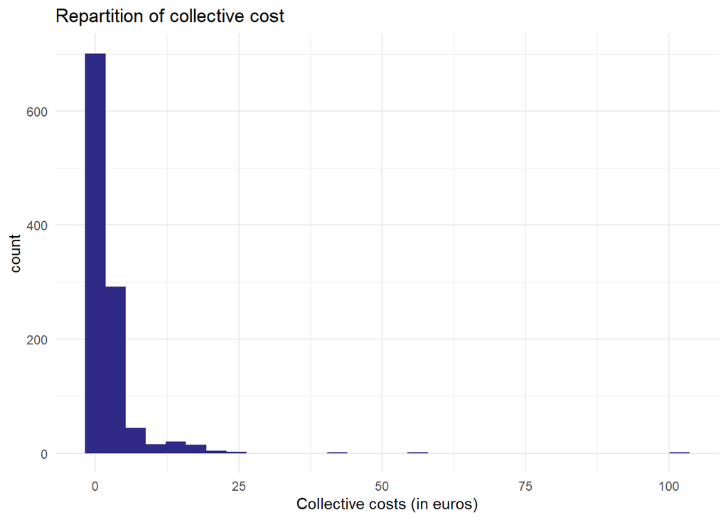

Figure 8: Collective cost repartition

### 3.2.1 Collective by distance

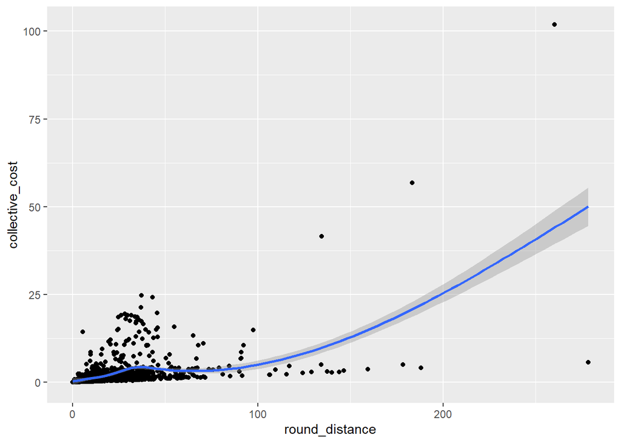

Figure 9: Collective cost by distance

## 3.3 Environmental costs

Estimated emissions by polluant

#### 3.3.0.1 CO_g

| min | mean | median | max |
| --- | --- | --- | --- |
| 0.02 | 50 | 12 | 4704 |

#### 3.3.0.2 COV_g

| min | mean | median | max |
| --- | --- | --- | --- |
| 0.01 | 7.7 | 3.7 | 415 |

#### 3.3.0.3 NOX_g

| min | mean | median | max |
| --- | --- | --- | --- |
| 0.06 | 86 | 37 | 1613 |

#### 3.3.0.4 NH3_g

| min | mean | median | max |
| --- | --- | --- | --- |
| 0 | 0.38 | 0.16 | 13 |

#### 3.3.0.5 PB_g

| min | mean | median | max |
| --- | --- | --- | --- |
| 0 | 0 | 0 | 0.01 |

#### 3.3.0.6 SO2_g

| min | mean | median | max |
| --- | --- | --- | --- |
| 0 | 0.04 | 0.02 | 1.8 |

#### 3.3.0.7 PS_g

| min | mean | median | max |
| --- | --- | --- | --- |
| 0 | 7.9 | 0.16 | 180 |

#### 3.3.0.8 CO2_g

| min | mean | median | max |
| --- | --- | --- | --- |
| 74 | 33481 | 22396 | 686419 |

#### 3.3.0.9 N2O_g

| min | mean | median | max |
| --- | --- | --- | --- |
| 0 | 0.61 | 0.39 | 33 |

#### 3.3.0.10 CH4_g

| min | mean | median | max |
| --- | --- | --- | --- |
| 0 | 0.35 | 0.03 | 12 |

# 4 Vehicule analysis

Table 9: Repartition of all vehicles, by type

| vhl_type | count |
| --- | --- |
| light utility vehicle | 1018 |
| personal vehicule | 61 |
| truck | 18 |

Table 10: Repartition of all vehicles, by motorisation

| motorisation | count |
| --- | --- |
| diesel | 1052 |
| essence | 45 |

## 4.1 Private vehicle

Table 11: Repartition of personal vehicles, by emission class

| id_vehicule | description | count |
| --- | --- | --- |
| VP_34 | Euro 6 (diesel) | 16 |
| VP_20 | Euro 2 (essence) | 12 |
| VP_41 | Euro 6 (diesel) | 12 |
| VP_33 | Euro 5 (diesel) | 7 |
| VP_28 | Euro 0 (diesel) | 6 |
| VP_32 | Euro 4 (diesel) | 2 |
| VP_6 | Euro 2 (essence) | 2 |
| VP_14 | Euro 3 (essence) | 1 |
| VP_22 | Euro 4 (essence) | 1 |
| VP_31 | Euro 3 (diesel) | 1 |
| VP_7 | Euro 3 (essence) | 1 |

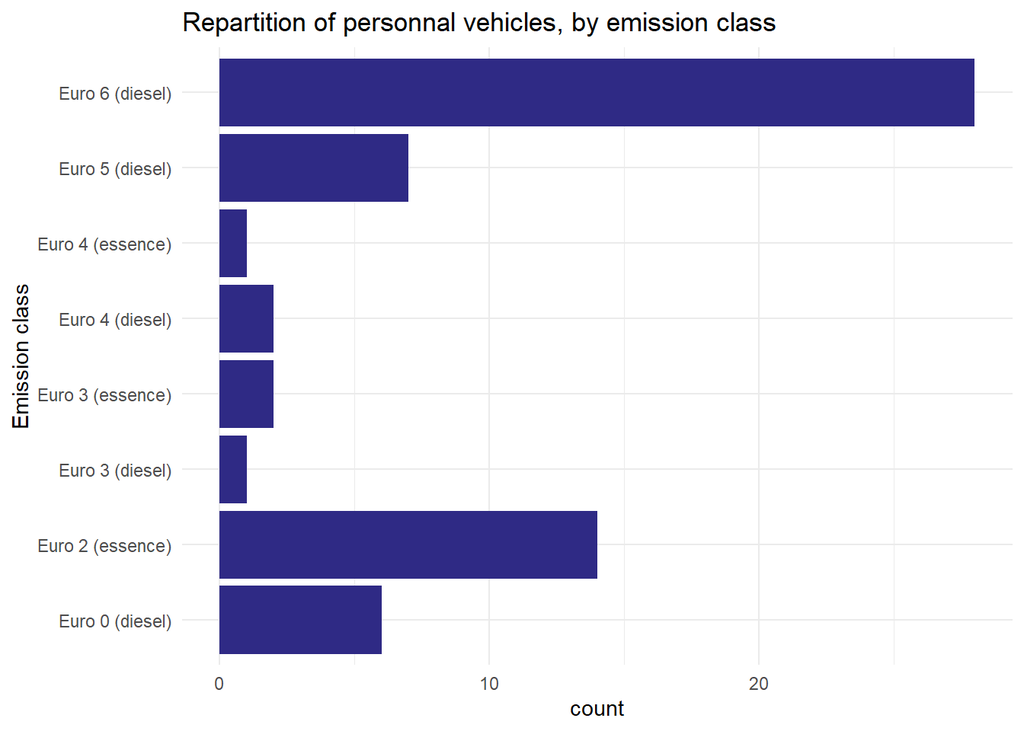

Figure 10: Repartition of personnal vehicles, by emission class

## 4.2 Light utility vehicle

Table 12: Repartition of light utility vehicles, by emission class

| id_vehicule | description | count |
| --- | --- | --- |
| VUL_14 | Euro 6 (diesel) | 454 |
| VUL_13 | Euro 5 (diesel) | 197 |
| VUL_12 | Euro 4 (diesel) | 157 |
| VUL_11 | Euro 3 (diesel) | 83 |
| VUL_8 | Euro 0 (diesel) | 67 |
| VUL_10 | Euro 2 (diesel) | 30 |
| VUL_2 | Euro 1 (essence) | 11 |
| VUL_7 | Euro 6 (essence) | 10 |
| VUL_5 | Euro 4 (essence) | 3 |
| VUL_6 | Euro 5 (essence) | 3 |
| VUL_9 | Euro 1 (diesel) | 3 |

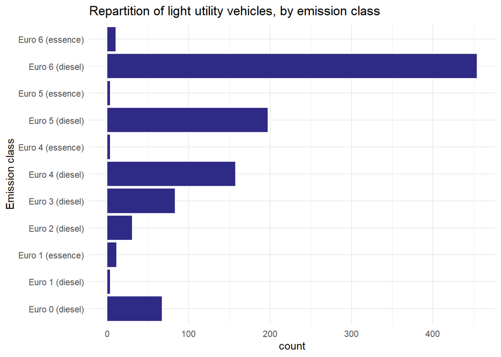

Figure 11: Repartition of light utility vehicles, by emission class

## 4.3 Trucks

Table 13: Truck repartition by emission class

| id_vehicule | description | count |
| --- | --- | --- |
| PL_25 | Euro 2 (diesel) | 7 |
| PL_5 | Euro 3 (diesel) | 3 |
| PL_15 | Euro 6 (diesel) | 2 |
| PL_21 | Euro 5 (diesel) | 2 |
| PL_29 | Euro 6 (diesel) | 2 |
| PL_1 | Euro 0 (essence) | 1 |
| PL_22 | Euro 6 (diesel) | 1 |

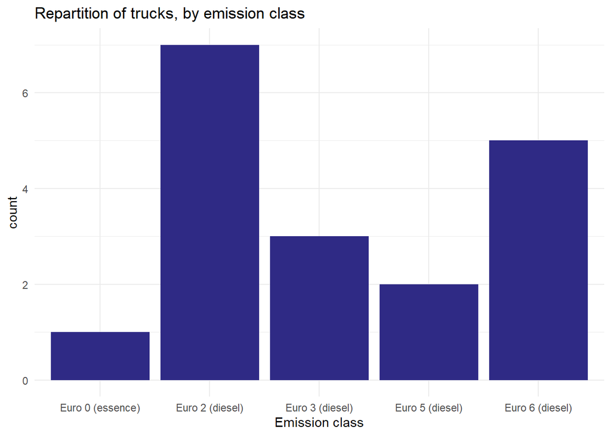

Figure 12: Repartition of trucks, by emission class

## 4.4 Deliveries by vehicule type

Table 14: Number of delivery points by vehicle type

| vhl_type | delivery_points |
| --- | --- |
| light utility vehicle | 5658 |
| personal vehicule | 276 |
| truck | 43 |

Table 15: Delivery points by vehicle type

| Vehicle type | min | mean | median | max |
| --- | --- | --- | --- | --- |
| light utility vehicle | 1 | 5.6 | 4 | 40 |
| personal vehicule | 1 | 4.5 | 3 | 21 |
| truck | 1 | 2.4 | 2 | 7 |